# Communicate_Data_Findings slides

### What is the structure of your dataset?

There are 183,412 rides with 15 features. Some are numeric (duration_sec, start_station_latitude, start_station_longitude, end_station_latitude, end_station_longitude, member_birth_year). The other datatypes include datetime, string (station ids, station names, bike id, user categoties).

### What is/are the main feature(s) of interest in your dataset?

I'm most interested in figuring out how different factors contribute to the duration of rides and the number of rides.

### What features in the dataset do you think will help support your investigation into your feature(s) of interest?

I expect that there are certain stations busier than the others, meaning there are more rides associated with those stations. I also expect that younger members contribute to more rides.

# Univariate Exploration

I'll start by looking at the distribution of the ride duration.

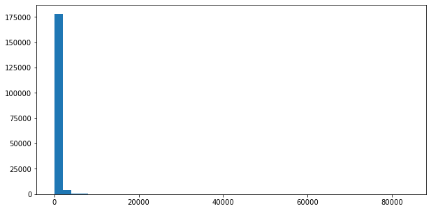

The duration time is severely skewed to the right, so let's zoom in to take a closer look:

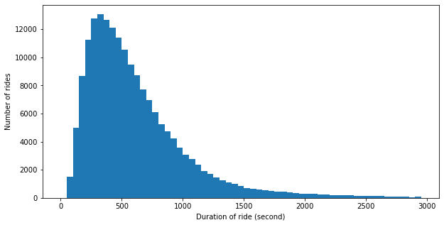

The long tail suggests that the ride duration might be more suitable for a log scale. Now let's perform a log transformation.

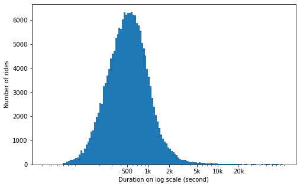

The ride duration duration has a very long tail, with the vast majority of the rides within 2,000 seconds (~30mins). When plotted on a log-scale, the distribution looks like a normal distribution, with the center locating at around 500 seconds.  
Next up, the first independent variable of interest: member age

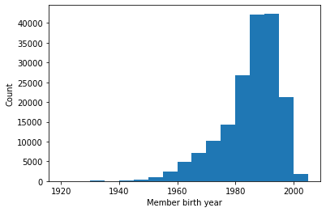

The distribution of member birth age is skewed to the left, meaning that most of the members are in the younger population. In particular, the peak of the distribution is at late 1980s and early 1990s. There seems to be one errenous entry: a woman is indicated to be born on 1878, and the row was dropped.  
Next, let's investigate another variable: stations.

```
The average number of rides starting at one station: 555.790909090909
```

```
The average number of rides ending at one station: 555.790909090909
```

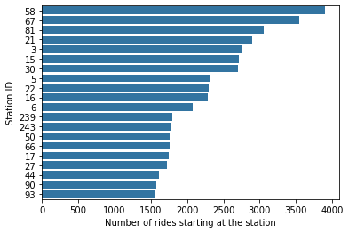

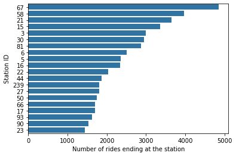

Let's explore the relationship between members' gender and the total number of rides each group contribtues.

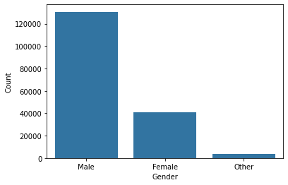

Next, let's compare how different types of users contribute to the total number of rides.

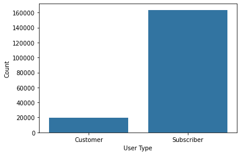

After exploring different groups of riders, let's investigate how the number of rides varies throughout the week.

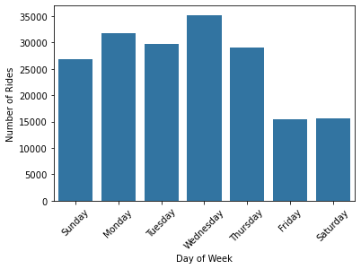

According to the histogram, the numbers of rides on Friday and Saturday are about half of the rides on the other days. Now let's investigate how the number of rides varies throughout the day.

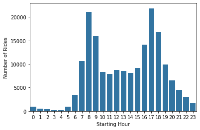

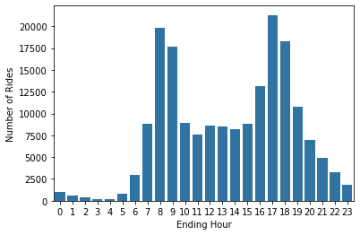

# Bivariate Exploration

First, explore the relationship between ride duration and birth duration.

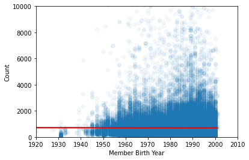

The scatterplot shows that even though younger members have more long-duration rides, there seems to be no correlation between the member age and ride duration. The reason is that even though there are more long rides for younger members, there are more short rides as well, and hence the average duration is not significantly impacted by the riders' age. Now let's investigate how different factors, including gender, user type, age groups, ride share, ride hour, can affect the ride duration

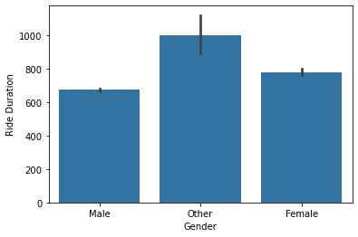

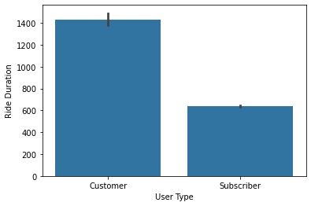

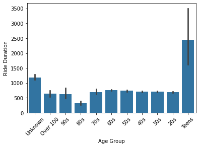

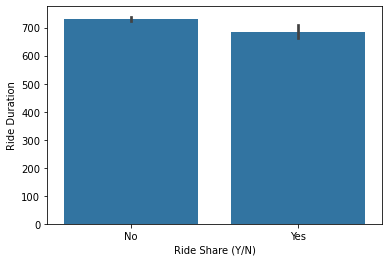

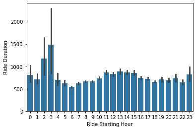

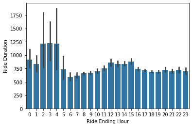

# Multivariate Exploration

This section investigate how the relationship between riders' age and ride duration might change with different types of riders/different day of the week. The biggest takeaway is: although members of different age have different number of rides and ride duration, the relationship of member age and ride duration is not impacted by rider type, gender, and day of the week.

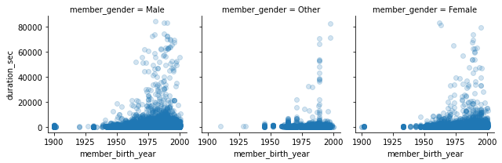

There is no siginificant difference in terms of the distribution of the birth year and the ride duration. Now, let's examine the relationship between the ride duration, birth year, and user type.

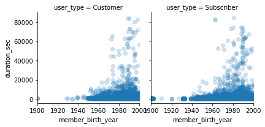

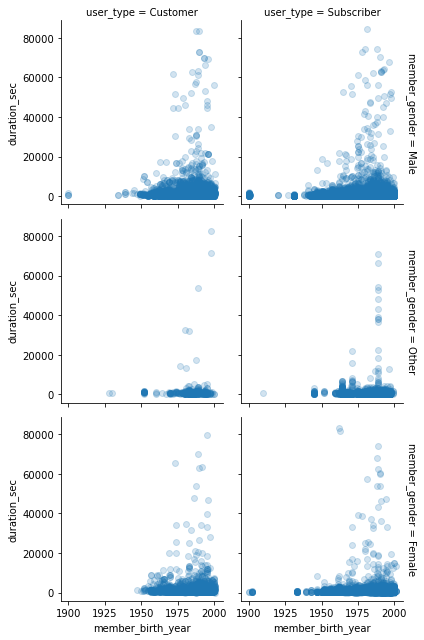

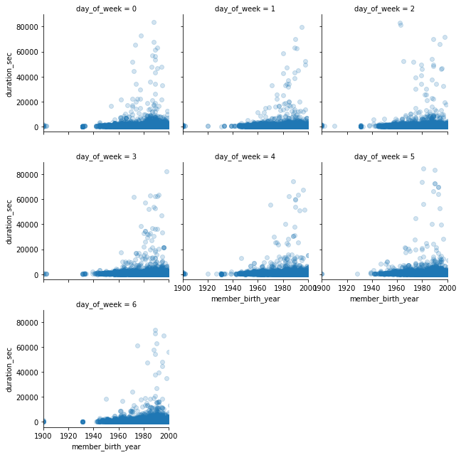